# Red Wine Analysis by Mark MacArdle

### Dataset introduction

1599 samples of red Portuguese “Vinho Verde” wines.

Description of attributes:

1. fixed acidity: most acids involved with wine or fixed or nonvolatile (do not evaporate readily)
2. volatile acidity: the amount of acetic acid in wine, which at too high of levels can lead to an unpleasant, vinegar taste
3. citric acid: found in small quantities, citric acid can add ‘freshness’ and flavor to wines
4. residual sugar: the amount of sugar remaining after fermentation stops, it’s rare to find wines with less than 1 gram/liter and wines with greater than 45 grams/liter are considered sweet
5. chlorides: the amount of salt in the wine
6. free sulfur dioxide: the free form of SO2 exists in equilibrium between molecular SO2 (as a dissolved gas) and bisulfite ion; it prevents microbial growth and the oxidation of wine
7. total sulfur dioxide: amount of free and bound forms of S02; in low concentrations, SO2 is mostly undetectable in wine, but at free SO2 concentrations over 50 ppm, SO2 becomes evident in the nose and taste of wine
8. density: the density of water is close to that of water depending on the percent alcohol and sugar content
9. pH: describes how acidic or basic a wine is on a scale from 0 (very acidic) to 14 (very basic); most wines are between 3-4 on the pH scale
10. sulphates: a wine additive which can contribute to sulfur dioxide gas (S02) levels, wich acts as an antimicrobial and antioxidant
11. alcohol: the percent alcohol content of the wine

Output variable (based on sensory data):

12. quality (score between 0 and 10). Median of at least 3 evaluations made by wine experts.

Units:

1. Fixed acidity (tartaric acid - g / dm^3)
2. volatile acidity (acetic acid - g / dm^3)
3. citric acid (g / dm^3)
4. residual sugar (g / dm^3)
5. chlorides (sodium chloride - g / dm^3)
6. free sulfur dioxide (mg / dm^3)
7. total sulfur dioxide (mg / dm^3)
8. density (g / cm^3)
9. pH
10. sulphates (potassium sulphate - g / dm3)
11. alcohol (% by volume)
12. quality (score between 0 and 10)

```
## 'data.frame':    1599 obs. of  13 variables:
##  $ X                   : int  1 2 3 4 5 6 7 8 9 10 ...
##  $ fixed.acidity       : num  7.4 7.8 7.8 11.2 7.4 7.4 7.9 7.3 7.8 7.5 ...
##  $ volatile.acidity    : num  0.7 0.88 0.76 0.28 0.7 0.66 0.6 0.65 0.58 0.5 ...
##  $ citric.acid         : num  0 0 0.04 0.56 0 0 0.06 0 0.02 0.36 ...
##  $ residual.sugar      : num  1.9 2.6 2.3 1.9 1.9 1.8 1.6 1.2 2 6.1 ...
##  $ chlorides           : num  0.076 0.098 0.092 0.075 0.076 0.075 0.069 0.065 0.073 0.071 ...
##  $ free.sulfur.dioxide : num  11 25 15 17 11 13 15 15 9 17 ...
##  $ total.sulfur.dioxide: num  34 67 54 60 34 40 59 21 18 102 ...
##  $ density             : num  0.998 0.997 0.997 0.998 0.998 ...
##  $ pH                  : num  3.51 3.2 3.26 3.16 3.51 3.51 3.3 3.39 3.36 3.35 ...
##  $ sulphates           : num  0.56 0.68 0.65 0.58 0.56 0.56 0.46 0.47 0.57 0.8 ...
##  $ alcohol             : num  9.4 9.8 9.8 9.8 9.4 9.4 9.4 10 9.5 10.5 ...
##  $ quality             : int  5 5 5 6 5 5 5 7 7 5 ...
```

Checking the structure of the dataset there’s also a row counter variable “X” so there’s 13 columns in the dataframe.

# Univariate Plots Section

### Quality

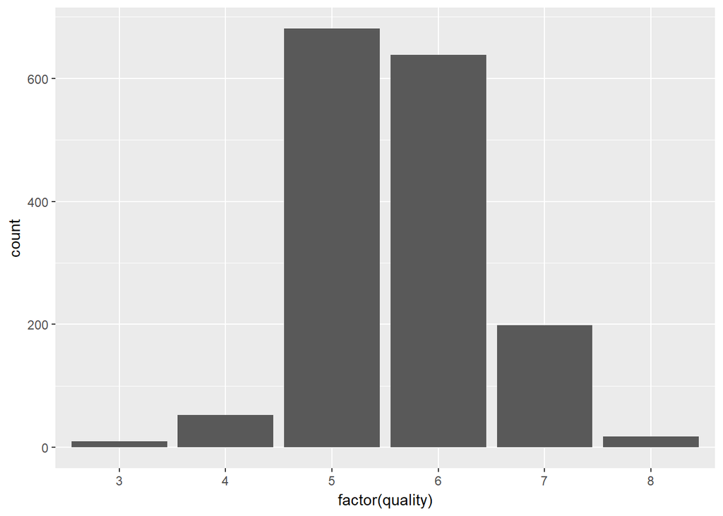

- 1 to 10 scale actual values are only between 3 and 8.
- Peak at 5 and 6. Makes sense as mean on a 1 to 10 scale would be 5.5
- Looks like there may be more wines above 5.5 than below.

This graph looks normally distributed, with a little positive skew as it looks like there’s a longer tail on the right of the graph. This makes sense as the quality scores are the median of at least 3 expert reviews. From the cental limit therom we can should expect to see a normal distribution, even if all the individual scores plotted a different distribution.

Creating a box plot to investigate further as I want to see the quartile ranges better. Overlaid a points plot get a better idea of the densities.

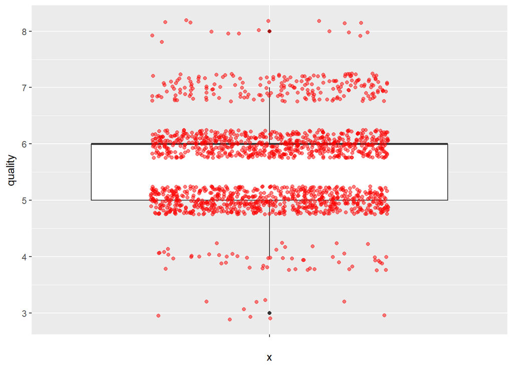

- Wines scoring 3 and 8 are identified as outliers.
- The median line can’t be seen as it’s at 6, on top of the 3rd quartile line.

### Alcohol

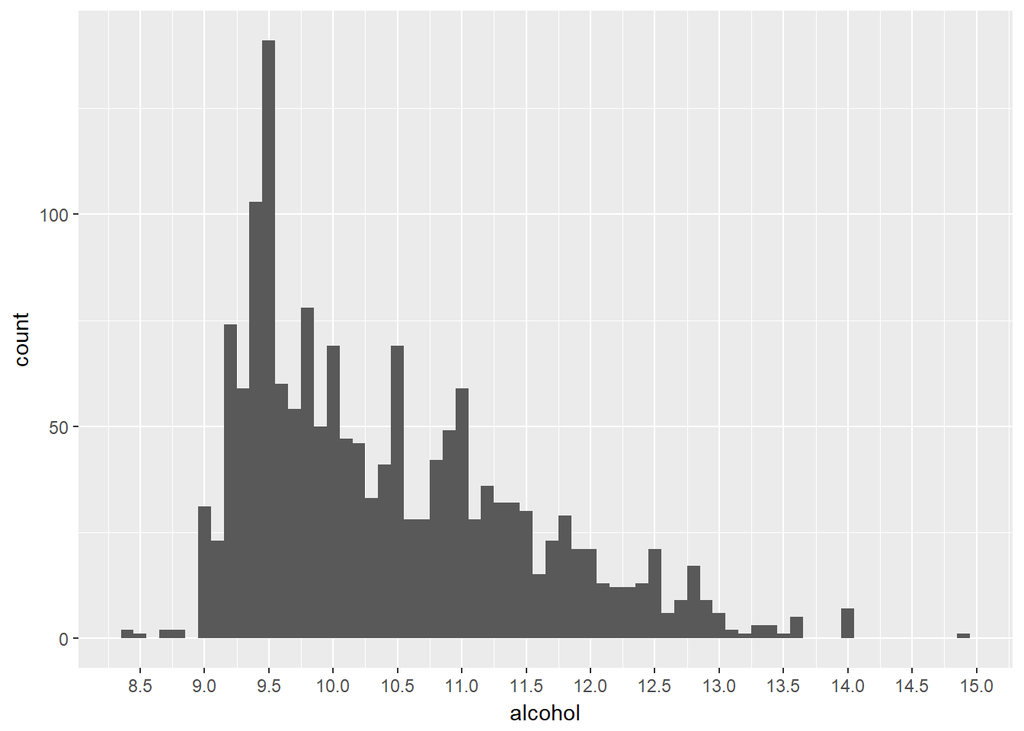

- Positively skewed distribution.
- Big peak at 9.5% and some other, smaller peaks at 10.5 and 11%. This is likely from a tendency to make alcohol levels to round numbers for marketing.

### Density

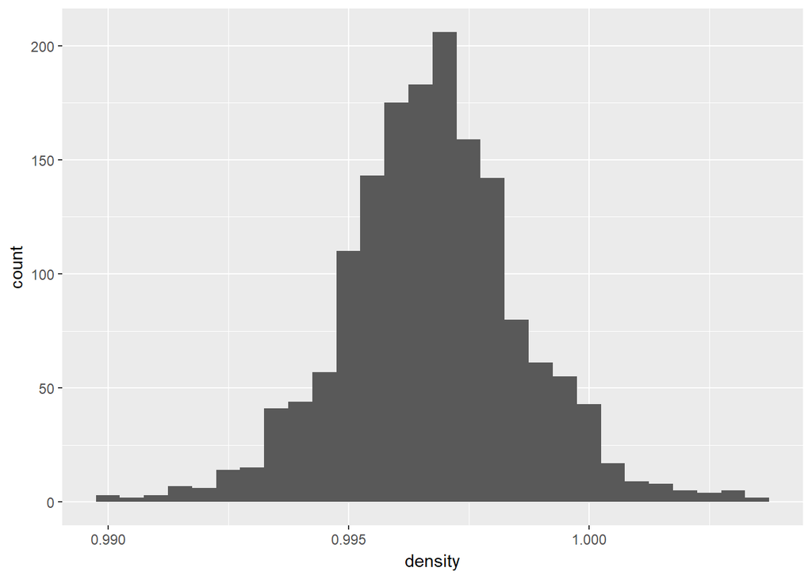

- Normally distributed
- Very small range.

### Acidity related variables

This is fixed.acidity, volatile.acidity, citric.acid and pH

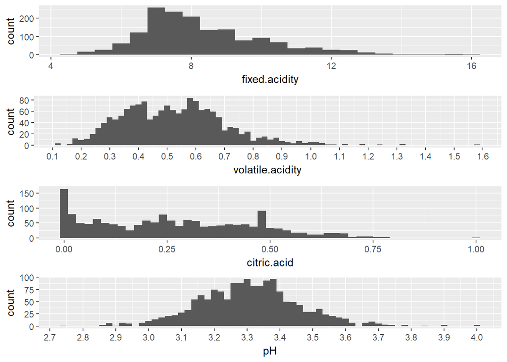

- fixed.acidity, volatile.acidity and citric.acid all positively skewed.
- volatile acidity has a bimodal distribution with peaks at roughly 0.42 and 0.58.
- citric.acid has an spike at just below 0.5.
- pH is normally distributed

I find it surprising that pH is normally distributed given the other acid variables are all skewed to lower levels. I expected pH would have been skewed towards more neutral (towards 7) with a long tail to lower pH values.

To investigate this further I’m creating a new variable that sums the 3 acid variables. They measure tartaric, acetic and citric acids and all have the same units of g/litre so can be added together without modification.

This will hopefully give a rough guide to total acidity but may be flawed if the three acids have very different strengths.

```r
wine$total.acids <- with(wine, fixed.acidity + volatile.acidity + citric.acid)
```

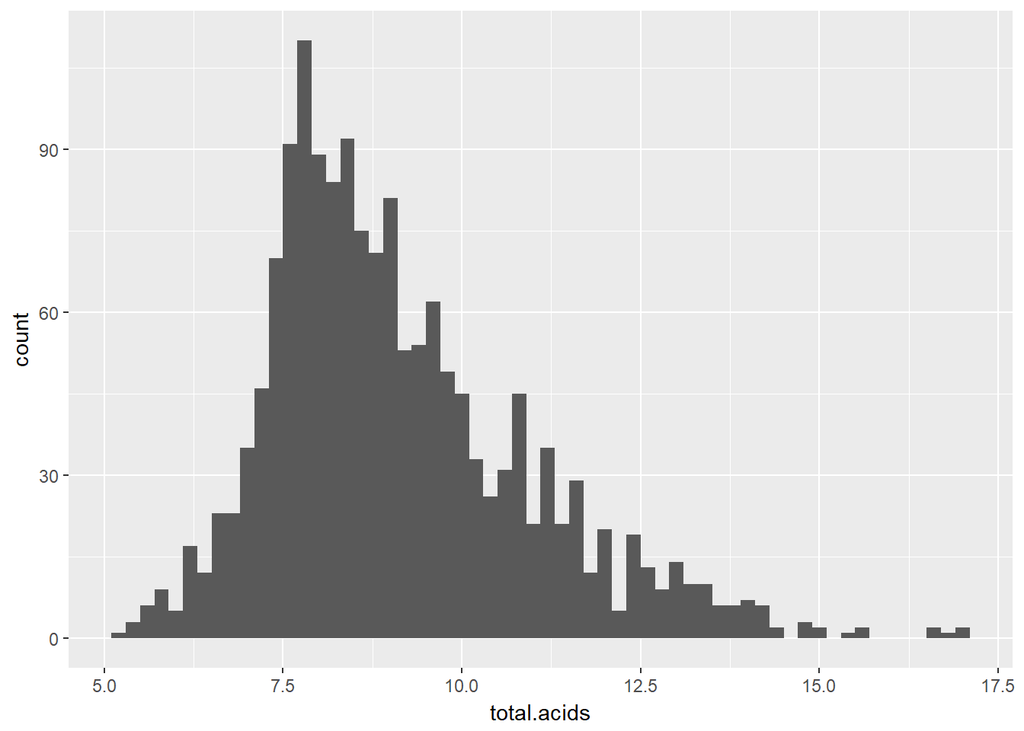

- Distibution is still a bit positively skewed.

### Sulphate and Sulpher Variables

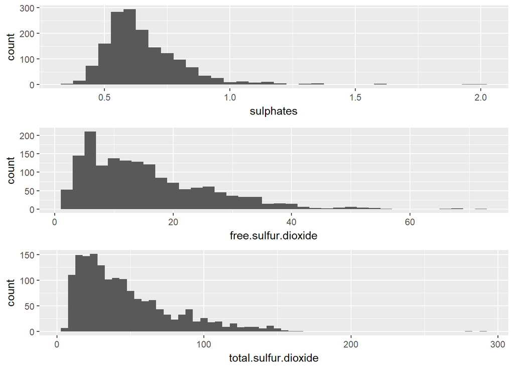

- All 3 are skewed to the right.

Total.sulfur.dioxide is the very skewed so may benefit from a log transformation

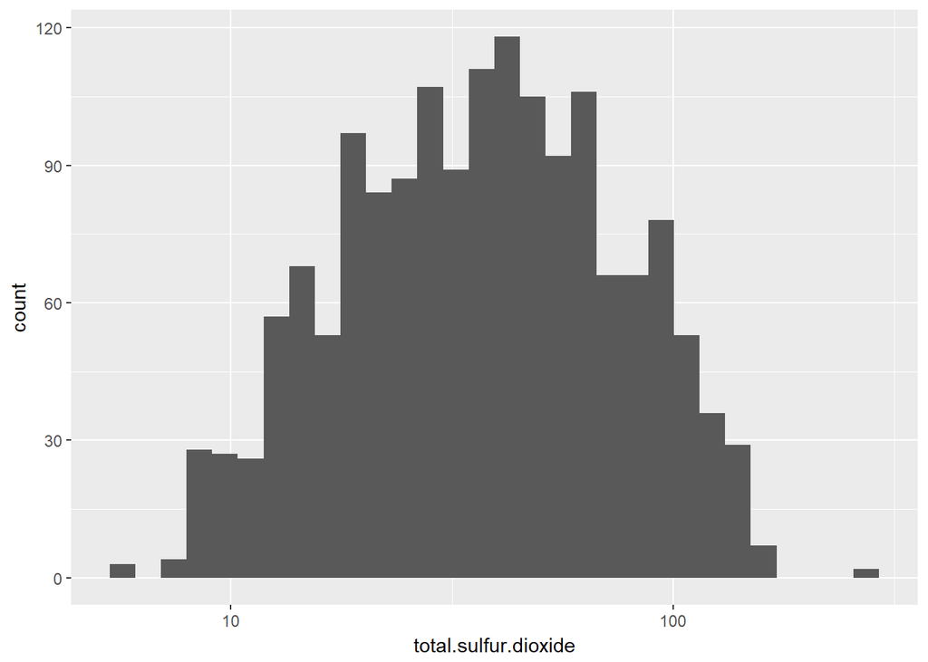

This gives a much more normal distribution which may be useful in later analysis.

### Salt and Sugar (chlorides and residual.sugar variables)

Looking at chlorides (which is the salt content) and residual.sugar variables together as these are two things that are normally labelled as bad for your health.

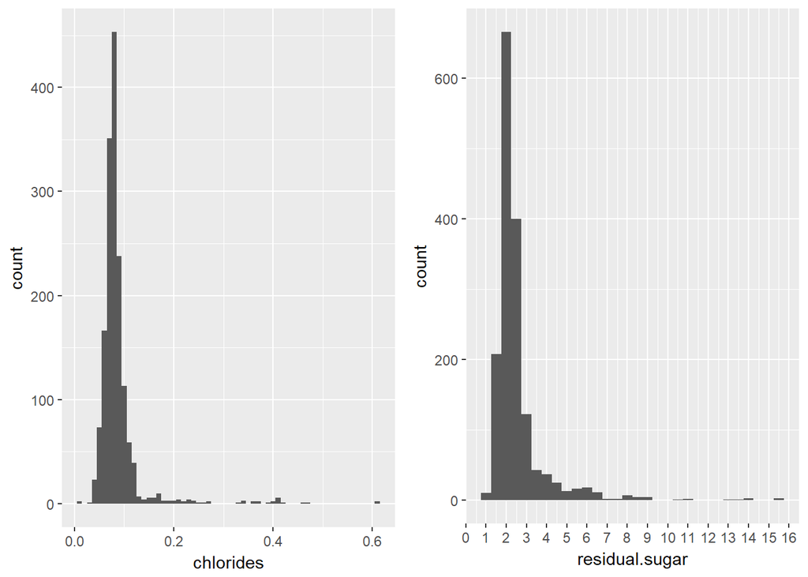

- similar distributions: big peaks low in the range and then a few much higher outliers.

In the bivariate analysis section I’ll investigate if it’s the same wines that have both high salt and sugar or if it’s more random.

# Univariate Analysis

### What is the structure of your dataset?

1599 observations of 11 input variables, which are all numeric, and one output variable for quality which is between 1 and 10.

The first column of the dataset is an ID variable that doesn’t contain any information past the row number.

### What is/are the main feature(s) of interest in your dataset?

The main feature of interest is quality. I want to look at what other variables influence this and if a predictive model can be made from them.

### What other features in the dataset do you think will help support your

### investigation into your feature(s) of interest?

I expect alcohol to have an effect on quality but it’s hard to know intuitively how the other variables will affect it. Correclations can be measured to gauge which are the most important though.

### Did you create any new variables from existing variables in the dataset?

Added total.acids to help investigate why pH is normally distibuted while the 3 different acids measured are all skewed to low levels. It will be interesting to look at the relationship of this new variable to pH in the bivariate section.

### Of the features you investigated, were there any unusual distributions?

### Did you perform any operations on the data to tidy, adjust, or change the

### form of the data? If so, why did you do this?

Citric.acid was unusual having a high spike at just below 0.5 and being fairly flat for most of it’s distribution.

I was surprised to see that pH and density had normal distributions given that the variables that I expected to inflence them (fixed.acidity, volatile acidity and citric acid for pH and alcohol and residual.sugar for density) all had skewed distributions.

# Bivariate Plots Section

Creating a pairs matrix to get a quick idea of the variables and their correlations.

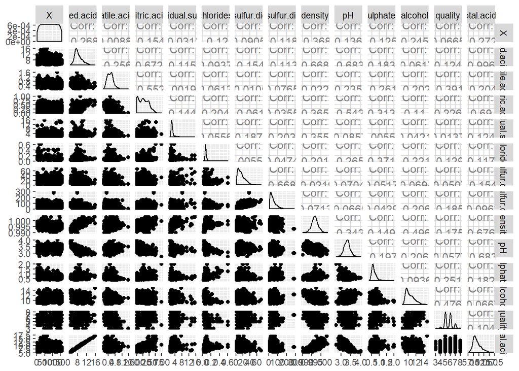

It’s hard to see the correlations values on plot when it’s not blown up to full screen so remaking a plot for just the correlations:

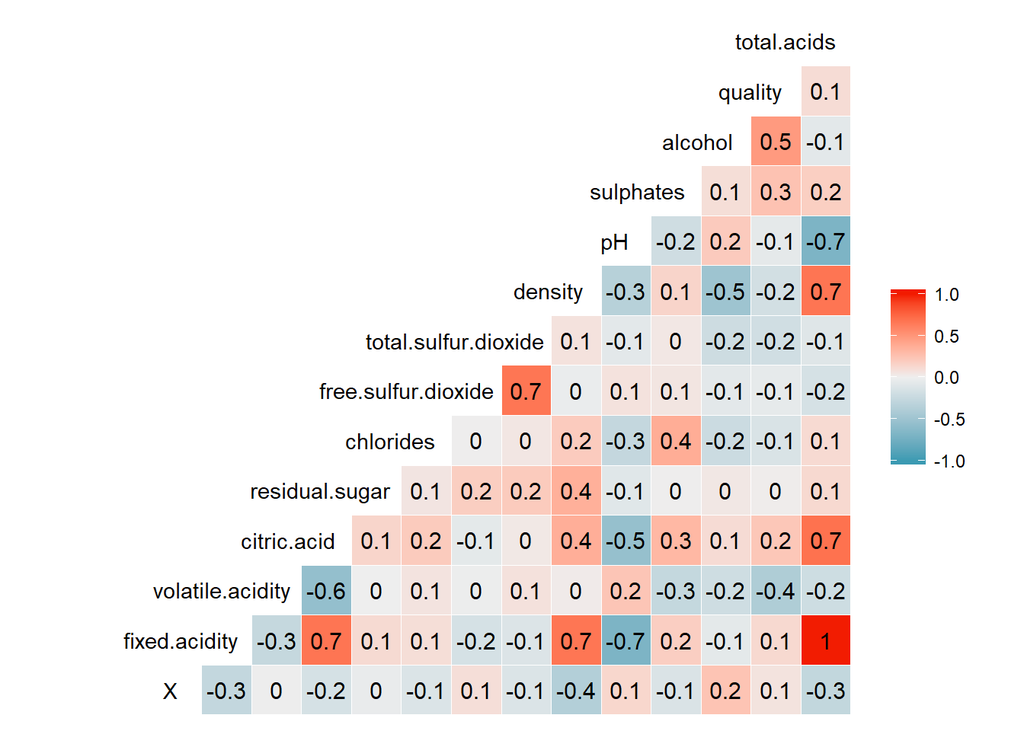

I see that alcohol and then volatile.acidity have the strongest correlations to quality so I shall start by looking at those.

The two correlations are:

```r
cor.test(wine$quality, wine$alcohol)
```

```
##
##  Pearson's product-moment correlation
##
## data:  wine$quality and wine$alcohol
## t = 21.639, df = 1597, p-value < 2.2e-16
## alternative hypothesis: true correlation is not equal to 0
## 95 percent confidence interval:
##  0.4373540 0.5132081
## sample estimates:
##       cor
## 0.4761663
```

```r
cor.test(wine$quality, wine$volatile.acidity)
```

```
##
##  Pearson's product-moment correlation
##
## data:  wine$quality and wine$volatile.acidity
## t = -16.954, df = 1597, p-value < 2.2e-16
## alternative hypothesis: true correlation is not equal to 0
## 95 percent confidence interval:
##  -0.4313210 -0.3482032
## sample estimates:
##        cor
## -0.3905578
```

### Quality Vs Alcohol

In the graph jitter has been added horizontally but not vertically.

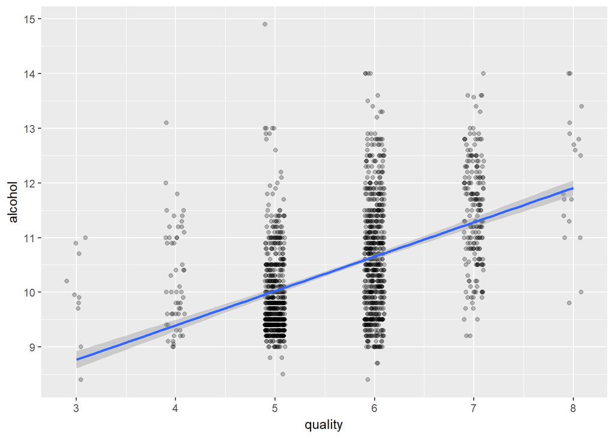

Remaking the graph as a boxplot.

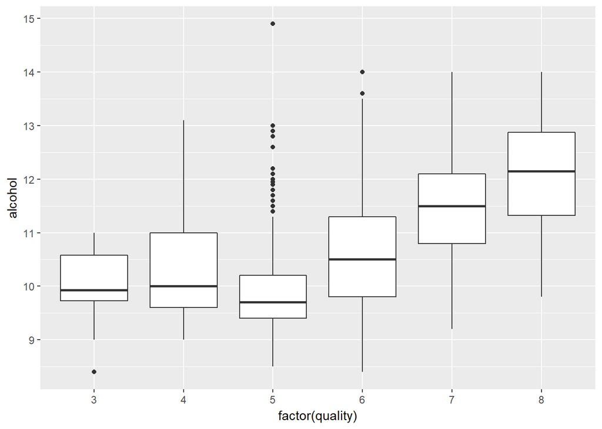

- There’s a lot of outliers in quality=5
- The change in median alcohol content is much clearer here than the linear regression line showed on the scatterplot. For quality=3, 4, 5 there’s not much change. However from quality=5 to 8 there’s a noticable step each time.
- The interquartile ranges for quality = 4, 6, 7, 8 are similar. It’s odd that quality=5 has such a small range with so many outliers.

### Quality Vs volatile.acidity

Looking at volatile.acidity with quality with width but no height jitter.

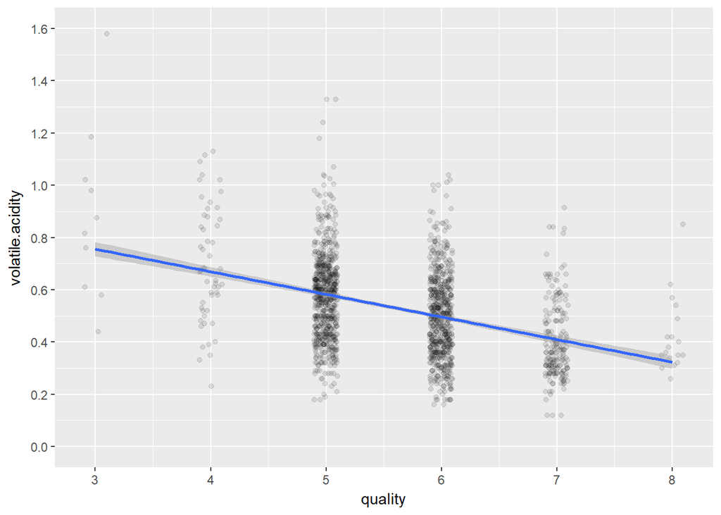

Creating a box plot of the same thing.

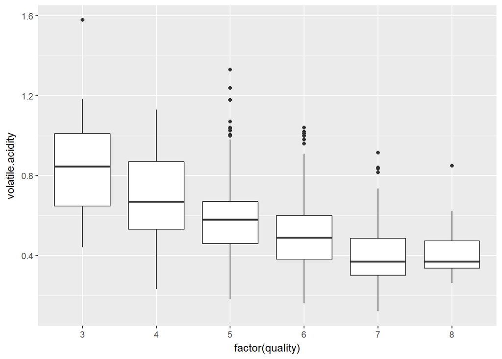

- Shows a fairly linear decreasing trend between the medians from quality = 3 to 7. Then 7 and 8 are similar.
- Like the quality vs alcohol graph again shows a lot of outliers for quality=5.

### Alcohol Vs volatile.acidity

As these two variables have the highest correlations with quality it is worth seeing if they have a correlation with each other. If they have a strong correlation to each other that would imply they’re explaining the same part of quality’s variation. It would be more interesting if they realatively independent as then they can be used to explain more of variation in quality and would allow for better prediction of it.

Checking the correlation first

```
##
##  Pearson's product-moment correlation
##
## data:  wine$alcohol and wine$volatile.acidity
## t = -8.2546, df = 1597, p-value = 3.155e-16
## alternative hypothesis: true correlation is not equal to 0
## 95 percent confidence interval:
##  -0.2488416 -0.1548020
## sample estimates:
##       cor
## -0.202288
```

A correlation of -0.2 isn’t very big. The scatterplot below illustrates this with a linear regression line with a small negative slope. That is to say that higher alcohol levels have generally lower acidity levels.

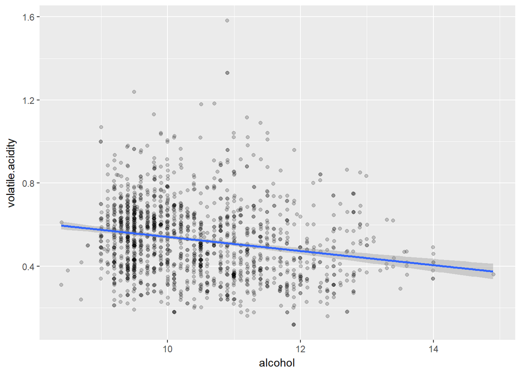

### Other Acidity Variables

Using ggpairs on just the acidity and quality variables.

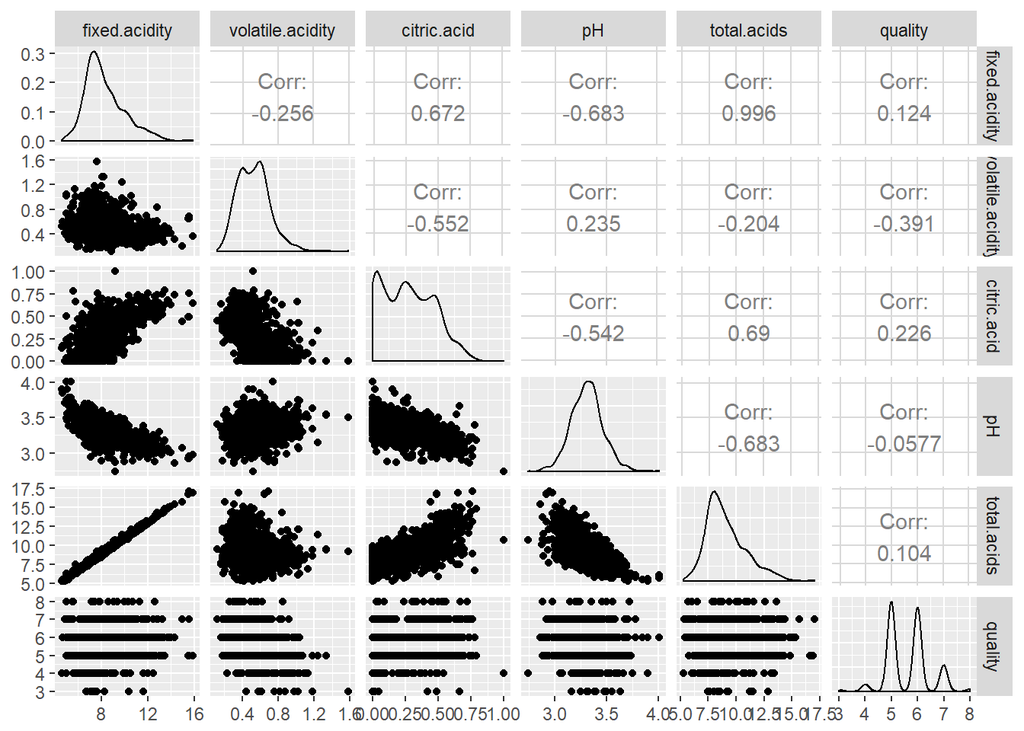

The very linear scatterplot between fixed.acidity and total.acids stands out and highlights something I hadn’t realised when I made the total.acids variable. The range of fixed.acidity is far greater than volatile.acidity or citric acid. Due to this total.acids is nearly equal to fixed.acidity. Their correlation is also nearly perfect at 0.996 which futher illustrates this point.

This makes total.acids irrelevant as fixed.acidity can be used in its place.

What would may be more useful is if total.acids was change to sum of normalised acids. The 3 acid variables divided by their ranges.

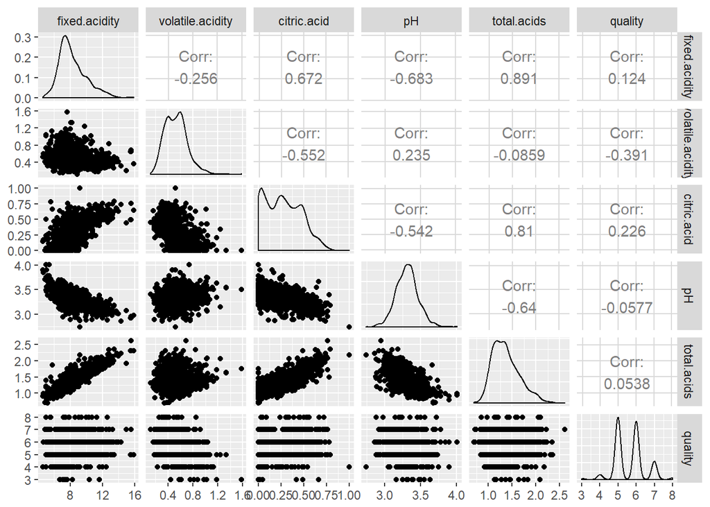

````r
#normalise each variable by dividing by its range (max - min)
wine$total.acids <- with(wine,
                         fixed.acidity /
                           (max(fixed.acidity ) - min(fixed.acidity))
                         +
                           volatile.acidity /
                           (max(volatile.acidity) - min(volatile.acidity))
                         +
                           citric.acid /
                           (max(citric.acid) - min(citric.acid)))

#```{r echo=FALSE, message=FALSE, warning=FALSE}
ggpairs(wine[, c("fixed.acidity", "volatile.acidity", "citric.acid",
                 "pH", "total.acids", "quality")])
````

total.acid is now a more interesting variable. It shows a high correlation with both fixed.acidity and citric.acid but not volatile.acidity. It’s interesting that volatile.acidity doesn’t move with the other two.

Unfortunately total.acid’s correlation to pH is lower than fixed.acidity and its correlation to quality is lower than the 4 other acid variables so I’m not sure if I’ll use it any further.

Below the relationship between fixed.acidity and pH is shown. The relationship betweent the two isn’t great and doesn’t fit a curving or linear line that well.

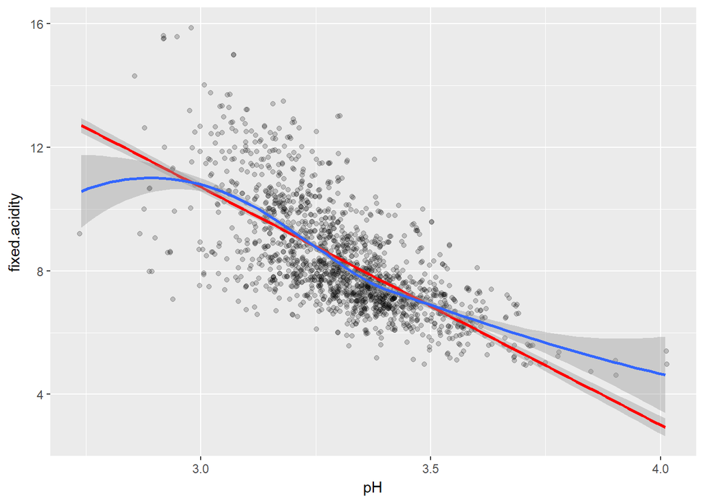

Citric acid has a small relationship with quality and may be useful when modelling it.

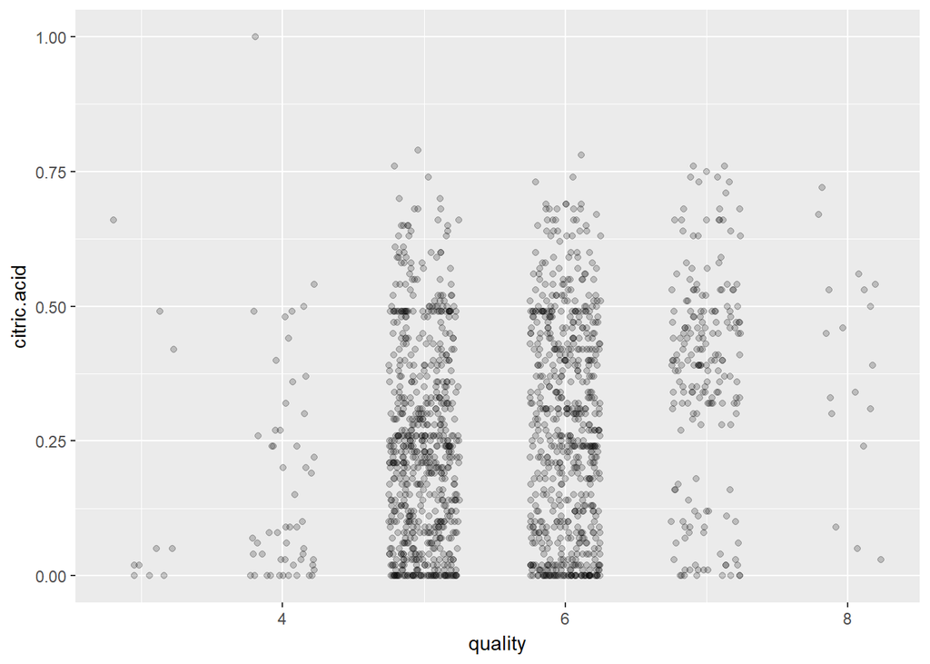

- There’s an odd gap in quality=7 and 8 values of citric acid around 0.25. I don’t know what could be the cause of this.

### Sulphate and Sulpher Variables

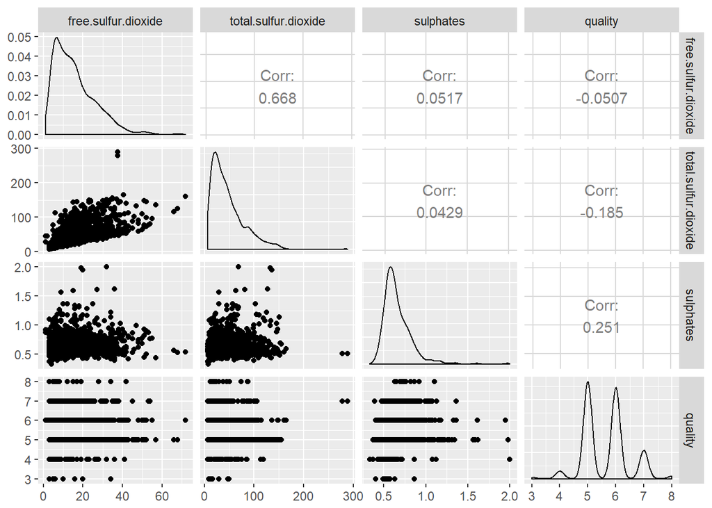

- Although still small sulphates has the higest correlation to quality
- Only total and free.sulfur.dioxide have a high correlation to each other here.

The difference between free and total sulfur dioxide is “bound” sulfur dioxide. I wonder if a variable for this might yield any more information.

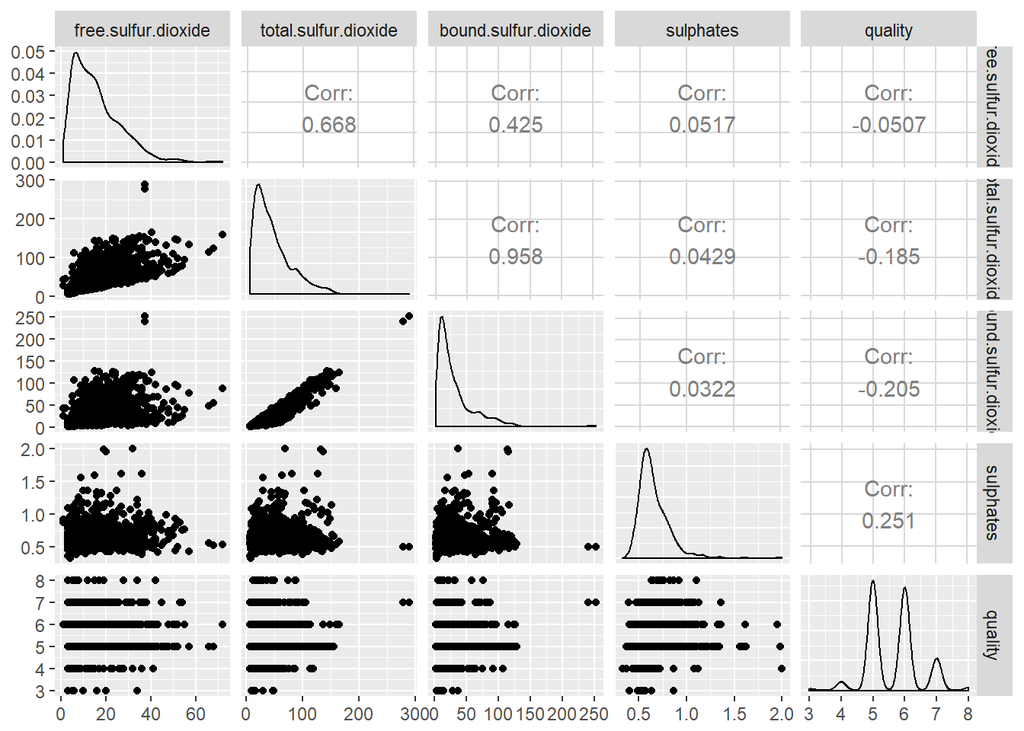

The bound.sulfur.dioxide has a higher correlation with quality and an even lower correlation with sulphates. Although bound SO2 and sulphates only have low correlations with quality, the fact they don’t correlate well with each other suggests they explain different parts to the variation in quality. This will be useful when making a model for quality.

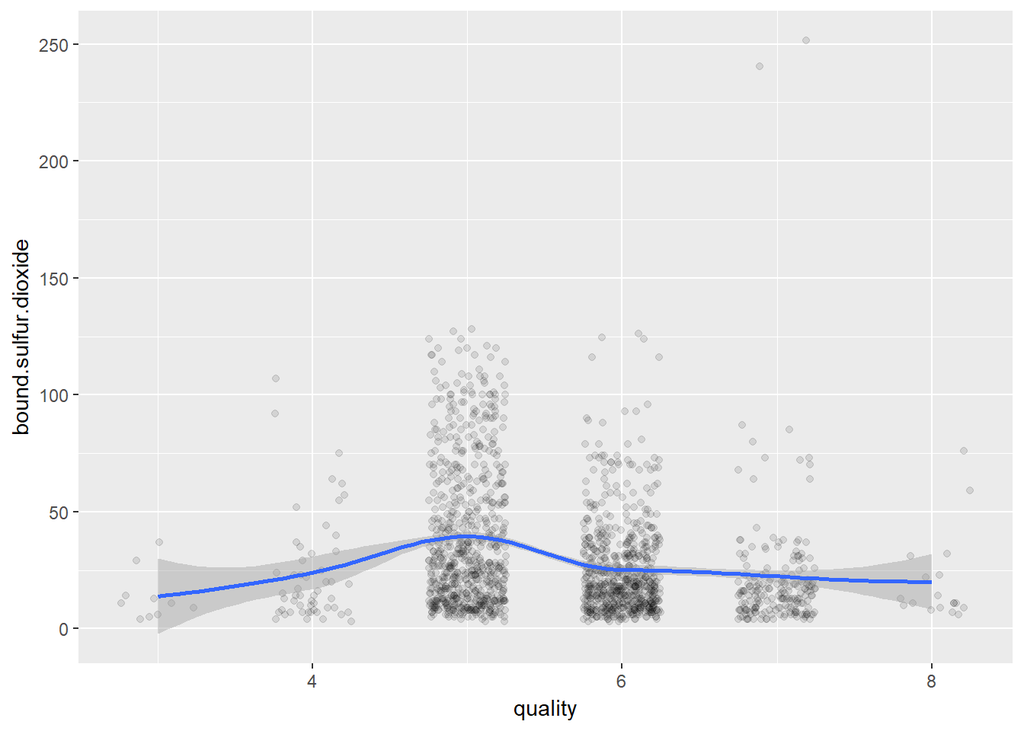

- An hump at quality=5 and 6 with lower values for 7 and 8.
- Two very high outliers at 7.
- The relatively flat best fit line show there’s only a small correlation here.

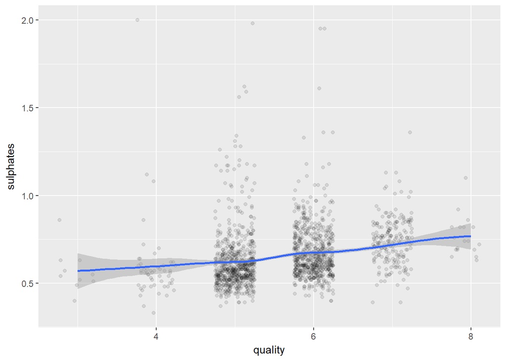

- Again only a small correlation visible.

### Salt Vs Sugar

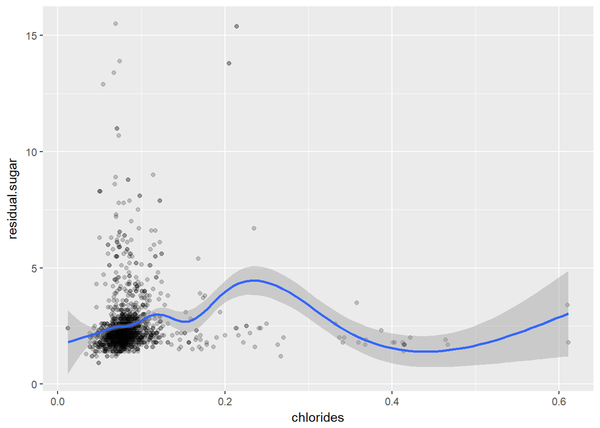

Checking the correlation to quantify the relationship.

```r
cor.test(wine$chlorides, wine$residual.sugar)
```

```
##
##  Pearson's product-moment correlation
##
## data:  wine$chlorides and wine$residual.sugar
## t = 2.2257, df = 1597, p-value = 0.02617
## alternative hypothesis: true correlation is not equal to 0
## 95 percent confidence interval:
##  0.006606405 0.104346223
## sample estimates:
##        cor
## 0.05560954
```

At 0.05 there’s very little correlation between these two parameters.

# Bivariate Analysis

### Talk about some of the relationships you observed in this part of the

### investigation. How did the feature(s) of interest vary with other features

### in the dataset?

Alcohol and volatile.acidity had the strongest correlations to quality. Alcohol’s relationship was positive and volatile.acidity’s negative.

### Did you observe any interesting relationships between the other features

### (not the main feature(s) of interest)?

Bound.sulfur.dioxide and sulphates both have a small relationship with quality but not with each other. This may make them useful for explaining different parts of quality’s variation in a model.

### What was the strongest relationship you found?

I created a new variable called total.acid which was the sum of the three acid variables. It had a near perfect correlation to fixed.acidity and that helped me realise an oversight. Fixed.acidity is much bigger in magnitude than the other two acidity variables so when I summed them it accounted for nearly all the variation.

Due to this I modified the variable to be a sum of the 3 other variables normalised.

Aside from this pH and fixed.acidity had a high relationship of 0.68 which makes sense as they are two difference measures of acidity.

# Multivariate Plots Section

### Quality, alcohol and volatile.acidity

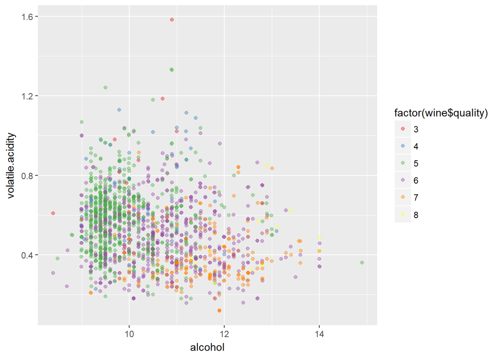

Recreating this graph as a facet grid shows these trends clearer:

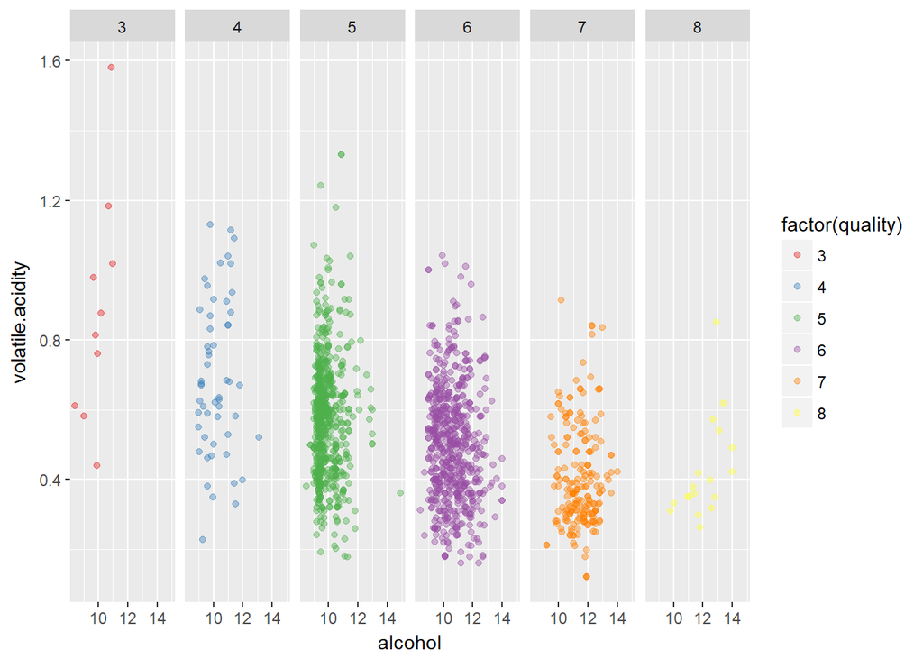

### Quality, Sulphates and Bound.sulfur.dioxide

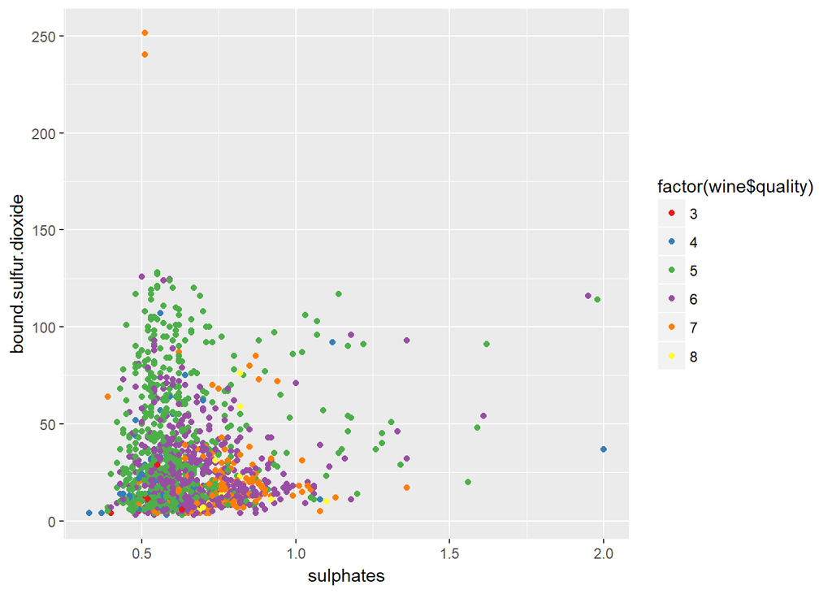

Some outliers make it hard to see what’s going on in the bottom left so will zoom in on that.

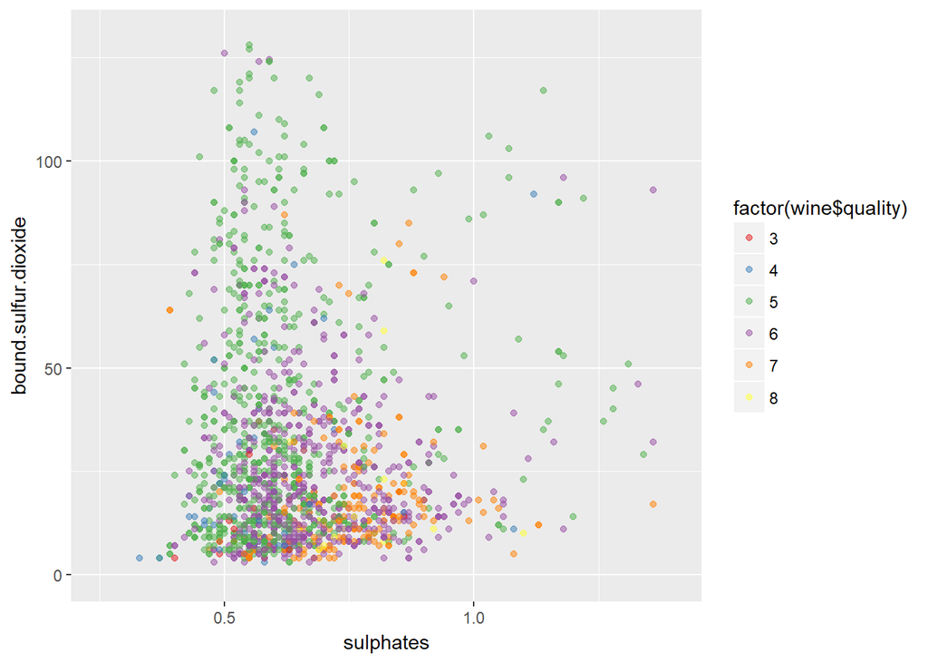

- For quality=5, 6, 7, 8 the mean can be seen moving up in sulphates and down in bound.sulfur.dioxide.

This can be better illustrated with summary points showing the mean values for each quality level as shown below.

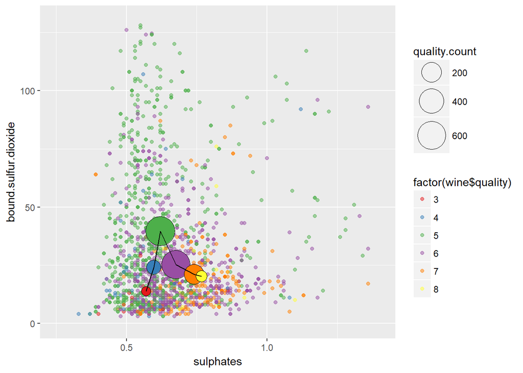

The line shows an interesting relationship with a peak in the middle. Seems like high leves of bound.sulfur.dioxide and low levels of sulphates can be associated with mediocraty.

### Quality, salt and sugar

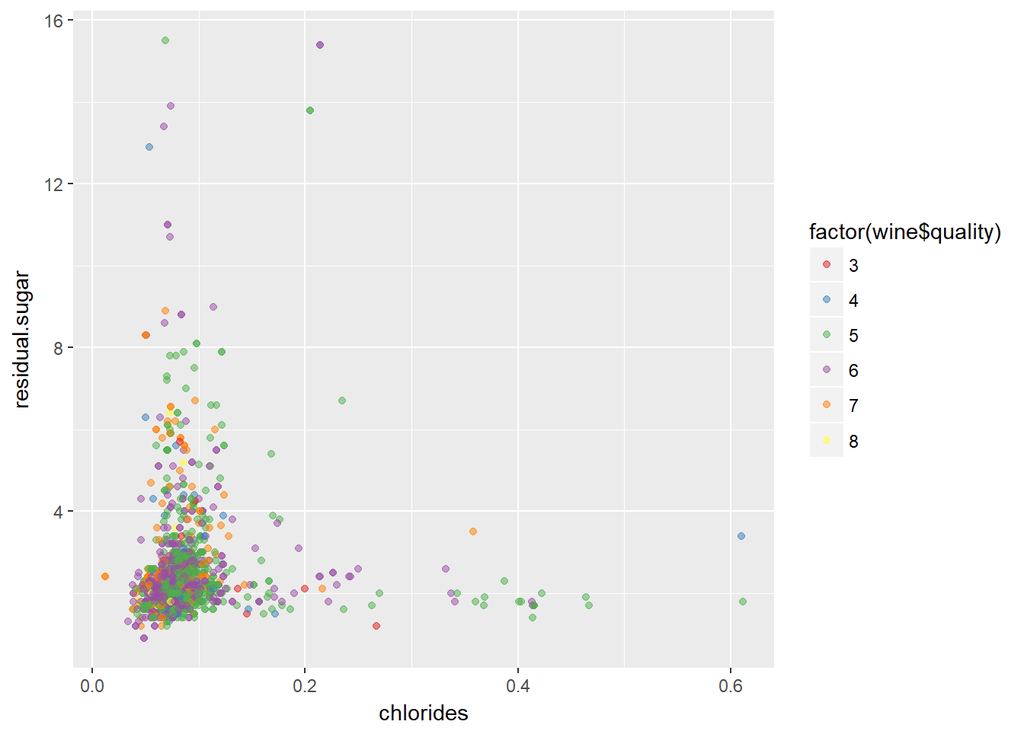

- Quality=5 are the most common high salt (chloride) wines.
- Quality=6 are the most common high sugar wines.
- There are very few quality=7 or 8 wines high in either salt or sugar.

It’s hard to see what’s going on in the dense cluster in the bottom left of the graph so creating the same graph with shorter limits to see it better.

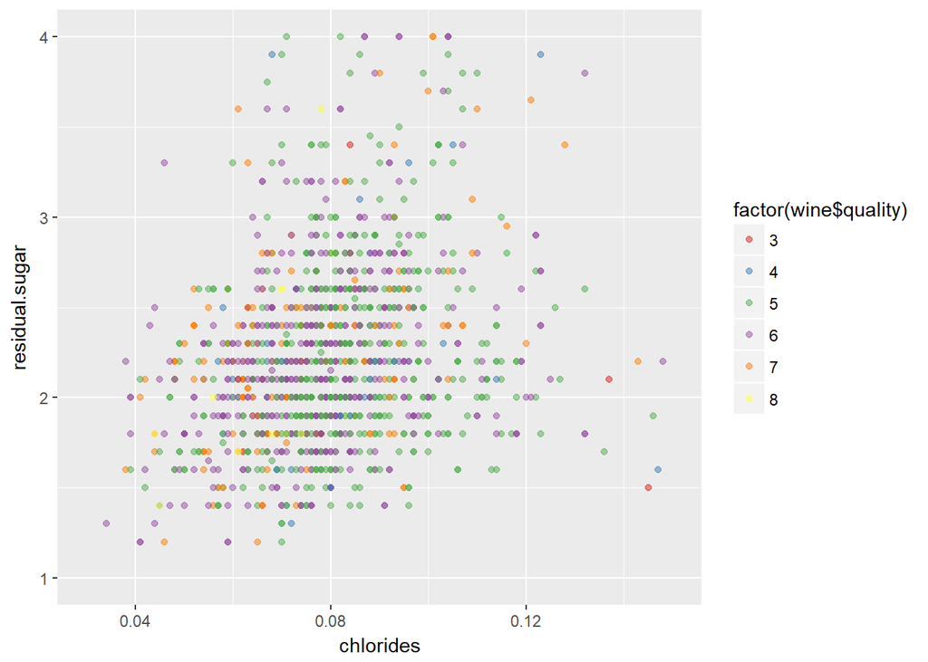

Looks pretty random so can’t draw any insights.

### Building a Linear Model

Showing the r code below so that it’s visible what variables are added to each model.

```r
m1 <- lm(quality ~ alcohol, data = wine)
m2 <- update(m1, ~ . + volatile.acidity)
m3 <- update(m2, ~ . + sulphates)
m4 <- update(m3, ~ . + bound.sulfur.dioxide)

#add all the other variables to a 5th variable just to see if it helps
m5 <- update(m4, ~ . + fixed.acidity + citric.acid + residual.sugar + chlorides +
               free.sulfur.dioxide + total.sulfur.dioxide + density + pH)

#need to have memisc library installed and loaded for mtable to work.
mtable(m1, m2, m3, m4, m5, sdigits = 3)
```

```
##
## Calls:
## m1: lm(formula = quality ~ alcohol, data = wine)
## m2: lm(formula = quality ~ alcohol + volatile.acidity, data = wine)
## m3: lm(formula = quality ~ alcohol + volatile.acidity + sulphates,
##     data = wine)
## m4: lm(formula = quality ~ alcohol + volatile.acidity + sulphates +
##     bound.sulfur.dioxide, data = wine)
## m5: lm(formula = quality ~ alcohol + volatile.acidity + sulphates +
##     bound.sulfur.dioxide + fixed.acidity + citric.acid + residual.sugar +
##     chlorides + free.sulfur.dioxide + total.sulfur.dioxide +
##     density + pH, data = wine)
##
## ==============================================================================================
##                              m1            m2            m3            m4            m5
## ----------------------------------------------------------------------------------------------
##   (Intercept)               1.875***      3.095***      2.611***      2.829***     21.965
##                            (0.175)       (0.184)       (0.196)       (0.200)      (21.195)
##   alcohol                   0.361***      0.314***      0.309***      0.293***      0.276***
##                            (0.017)       (0.016)       (0.016)       (0.016)       (0.026)
##   volatile.acidity                       -1.384***     -1.221***     -1.189***     -1.084***
##                                          (0.095)       (0.097)       (0.097)       (0.121)
##   sulphates                                             0.679***      0.712***      0.916***
##                                                        (0.101)       (0.100)       (0.114)
##   bound.sulfur.dioxide                                               -0.003***     -0.003***
##                                                                      (0.001)       (0.001)
##   fixed.acidity                                                                     0.025
##                                                                                    (0.026)
##   citric.acid                                                                      -0.183
##                                                                                    (0.147)
##   residual.sugar                                                                    0.016
##                                                                                    (0.015)
##   chlorides                                                                        -1.874***
##                                                                                    (0.419)
##   free.sulfur.dioxide                                                               0.001
##                                                                                    (0.002)
##   density                                                                         -17.881
##                                                                                   (21.633)
##   pH                                                                               -0.414*
##                                                                                    (0.192)
## ----------------------------------------------------------------------------------------------
##   R-squared                 0.227         0.317         0.336         0.345         0.361
##   adj. R-squared            0.226         0.316         0.335         0.343         0.356
##   sigma                     0.710         0.668         0.659         0.654         0.648
##   F                       468.267       370.379       268.912       209.910        81.348
##   p                         0.000         0.000         0.000         0.000         0.000
##   Log-likelihood        -1721.057     -1621.814     -1599.384     -1588.333     -1569.138
##   Deviance                805.870       711.796       692.105       682.603       666.411
##   AIC                    3448.114      3251.628      3208.768      3188.665      3164.277
##   BIC                    3464.245      3273.136      3235.654      3220.928      3234.179
##   N                      1599          1599          1599          1599          1599
## ==============================================================================================
```

After alcohol and volatile.acidity adding other variables has a limited effect in increasing R-squared.

However even the best R-squared value of 0.361 is not very high showing that this model is not very good at predicting a quality score from the variables.